# Visualization

Telling stories with plots in R

Welcome back! This week’s session will introduce you to the most important visualization approaches in R. 🎨

We will learn the fundamentals of data visualization with `ggplot` including bar plots, scatter plots, density plots, boxplots, histograms, correlation plots, heat maps, etc.

# Introduction to `ggplot2`

`ggplot2` is by far the most popular visualization package in **R**. `ggplot2` implements the **grammar of graphics** to render a versatile syntax of creating visuals. The underlying logic of the package relies on deconstructing the structure of graphs (if you are interested in this you can read this [article](http://vita.had.co.nz/papers/layered-grammar.pdf)). You can access the data visualization with `ggplot2` cheat sheet [here](https://rstudio.github.io/cheatsheets/data-visualization.pdf).

For the purposes of this introduction to data visualization with ggplot, we care about the layered approach taken by `ggplot2`.

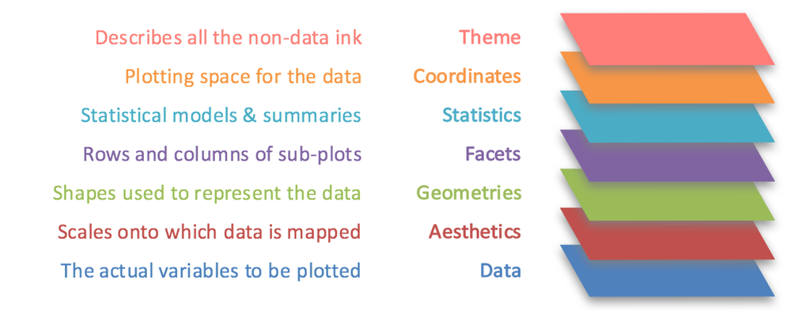

## Our building blocks 🧱

- **Data**: the data frame(s) we will use to plot
- **Aesthetics**: the variables we will be working with
- **Geometric objects**: the type of visualization
- **Theme adjustments**: size, text, colors, etc.

### Data

The first building block for our plots are the data we intend to map. In `ggplot2`, we always have to specify the object where our data lives. In other words, you will always have to specify a data frame, as such:

```r
ggplot(name_of_your_df)
```

Later on, we will see how to combine multiple data sources to build a single plot. For now, we will work under the assumption that all of your data live in the same object. Consider using `dplyr::left_join()`, `broom::augment()`, or similar functions to combine data sets or to complement your original data set with information from your models (e.g. fitted values).

### Aesthetics

The second building block for our plots is the aesthetics. We need to specify the variables in the data frame we will be using and what role they play.

To do this we will use the function `aes()` within the `ggplot()` function following the data frame.

```r
ggplot(name_of_your_df, aes(x = your_x_axis_variable, y = your_y_axis_variable))
```

Beyond defining your axes, you can add more aesthetics representing further dimensions of the data in the two-dimensional graphic plane such as size, color, and fill, just to name a few.

### Geometric objects

The third layer to render our graph (i.e., to produce a specific type of graph, e.g. bar plot, scatter plot, etc.) is a geometric object. To add one, we need to add a plus (`+`) at the end of the initial line of code and then state the type of geometric object we want to add. For example, `geom_point()` to produce a scatter plot or `geom_bar()` to produce a bar plot. For an overview of the most important functions and geoms available through `ggplot2`, see the `ggplot2` [cheat sheet](https://rstudio.github.io/cheatsheets/data-visualization.pdf).

```r
ggplot(name_of_your_df, aes(x = your_x_axis_variable, y = your_y_axis_variable)) +
  geom_point()
```

### Theme and Axes

At this point, our plot may just need some final touches. We may want to fix the axes names or get rid of the default gray background. To do so, we need to add an additional layer preceded by a plus sign (`+`).

If we want to change the names in our axes, we can utilize the `labs()` function.

We can also employ some of the pre-loaded themes, for example, `theme_minimal()`.

```r
ggplot(name_of_your_df, aes(x = your_x_axis_variable, y = your_y_axis_variable)) +
  geom_point() +
  theme_minimal() +
  labs(x = "Name you want displayed",
       y = "Name you want displayed")
```

```r
pacman::p_load(
  tidyverse,
  foreign,
  palmerpenguins,
  haven,
  gapminder,
  gridExtra,
  viridis
  )

df <- gapminder # let's make a copy of the data
str(df)
```

## Exercise 1 - Your first plot 🐧

For your first plot using `ggplot2`, we will use the `penguins` data set.

We would like to create a scatter plot that illustrates the relationship between the length of a penguin’s flipper and their weight.

To do so, we need three of our building blocks:

1. Data
2. Aesthetics
3. A geometric object (`geom_point()`)

Once we have our scatter plot, adapt the code to:

1. Use color to convey another variable (e.g., the species of penguin)
2. Change the axes names
3. Render the graph with `theme_minimal()`

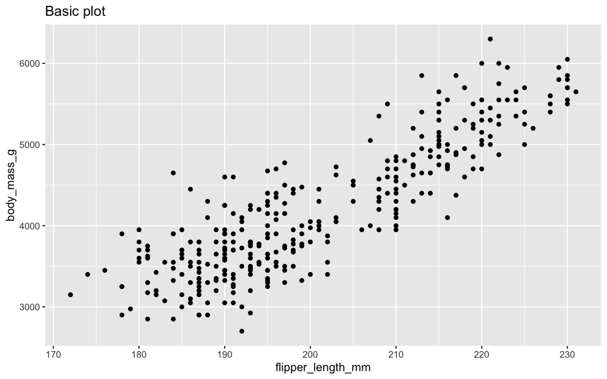

```r
ggplot(penguins, aes(x = flipper_length_mm, y = body_mass_g)) +
  geom_point() +
  labs(title = "Basic plot")
```

```r
# YOUR CODE HERE
```

That was the first step towards understanding the basic structure of the layers. Let’s have a closer look at what plot types makes sense in which situations. The question is, how can we convey the information most effectively?

# Plotting distributions 📊

If we are interested in plotting distributions of our data, we can leverage geometric objects such as:

- `geom_histogram()`: visualizes the distribution of a single continuous variable by dividing the x axis into bins and counting the number of observations in each bin (the default is 30 bins).
- `geom_density()`: computes and draws kernel density estimate, which is a smoothed version of the histogram.
- `geom_bar()`: renders bar plots and in plotting distributions behaves in a very similar way from `geom_histogram()` (can also be used with two dimensions)
- `geom_boxplot()`: box plots can show distributions of variables across groups (you could also consider them as plots for relationships: between a continuous and a categorical variable)

## Histograms

Histograms show the distribution of continuous variables. In this first example, we graph the distribution of the life expectancy variable (i.e., `lifeExp`) from the gapminder dataset.

```r
summary(df$lifeExp)
```

```
##    Min. 1st Qu.  Median    Mean 3rd Qu.    Max.
##    23.6    48.2    60.7    59.5    70.8    82.6
```

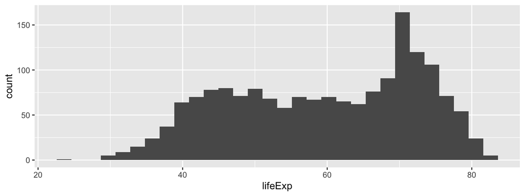

```r
ggplot(df,
       aes(x = lifeExp)) +
  geom_histogram()
```

> What conclusions might you draw from the histogram above about the distribution of life expectancy worldwide?

The default number of bins is 30, which means that the entire range of the variable (here 23.60 to 82.60) is split into 30 equally spaced bins. We can change the number of bins manually. Below, we specify 60 bins to approximate a bin width of 1 year, **taking into account the range of the variable** `lifeExp`.

```r
max(df$lifeExp) - min(df$lifeExp) # the range is approx 60 years
```

```
## [1] 59
```

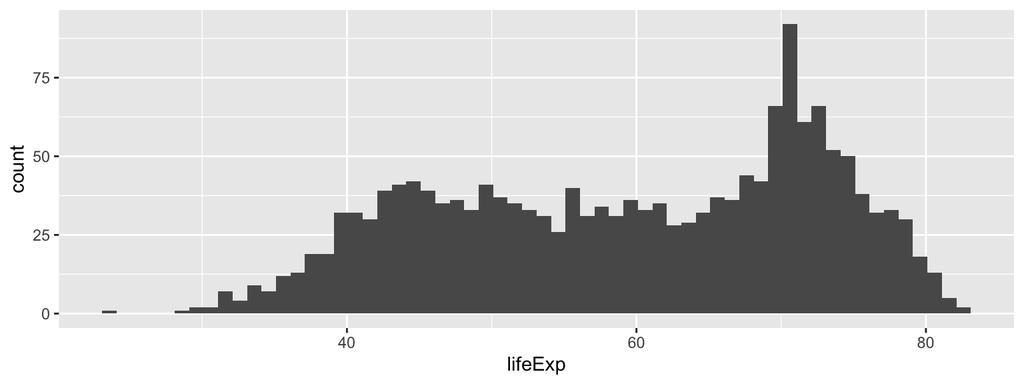

```r
ggplot(df, aes(x = lifeExp)) +
  geom_histogram(bins = 60)
```

What would happen if we specified 5 bins? Try it out.

```r
# YOUR CODE HERE
```

## Density plots

We saw that the shape of the distribution is highly influenced by *how many bins* we specify. If we specify too few, we run the risk of masking a lot of variation within the bins. If we specify too many bins, we trade parsimony for granularity – which might make it harder to draw conclusions about the overall distribution of the variable of interest from the graph.

Density plots are continuous alternatives to histograms that do not rely on bins. We will not cover details about the mechanics behind density plots and their estimation here. Just know that we can interpret the height of the density curve in a similar way to how we interpreted the height of the bars in a histogram: The higher the curve, the more observations we have at that specific value of the variable of interest. In this first example, we use the `geom_density()` function to create the density plot.

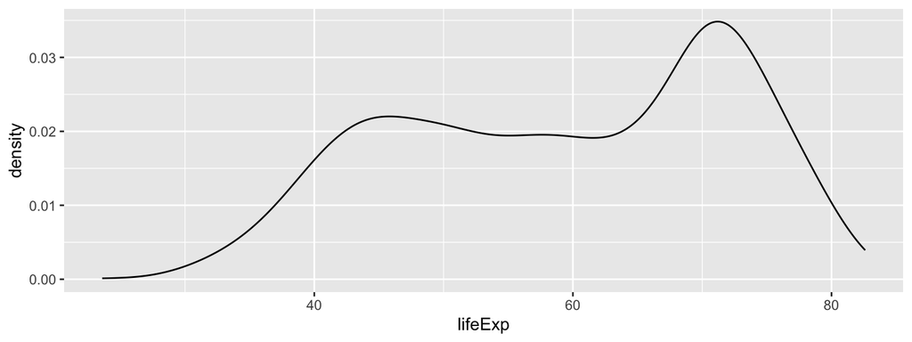

```r
ggplot(df, aes(x = lifeExp)) +
  geom_density()
```

## Boxplots 📦

Another way to show the distribution of variables across groups are boxplots. Boxplots graph different properties of a distribution:

- The borders of the box denote the 25th and 75th percentile.
- The line within the box denotes the median.
- The position of the whiskers (vertical lines) denote the first quantile value minus 1.5 times the interquartile range and the third quantile value plus 1.5 times the interquartile range.
- Dots denote outliers (values that lie outside the whiskers), if applicable.

In `ggplot2` we can graph boxplots across multiple variables using the `geom_boxplot()` geometric object. Here, the continuous variable (i.e. `lifeExp`) should be specified as the `y` variable, and the categorical variable (i.e. `continent`) as the `x` variable.

We can flip the axes by using the `coord_flip()` command.

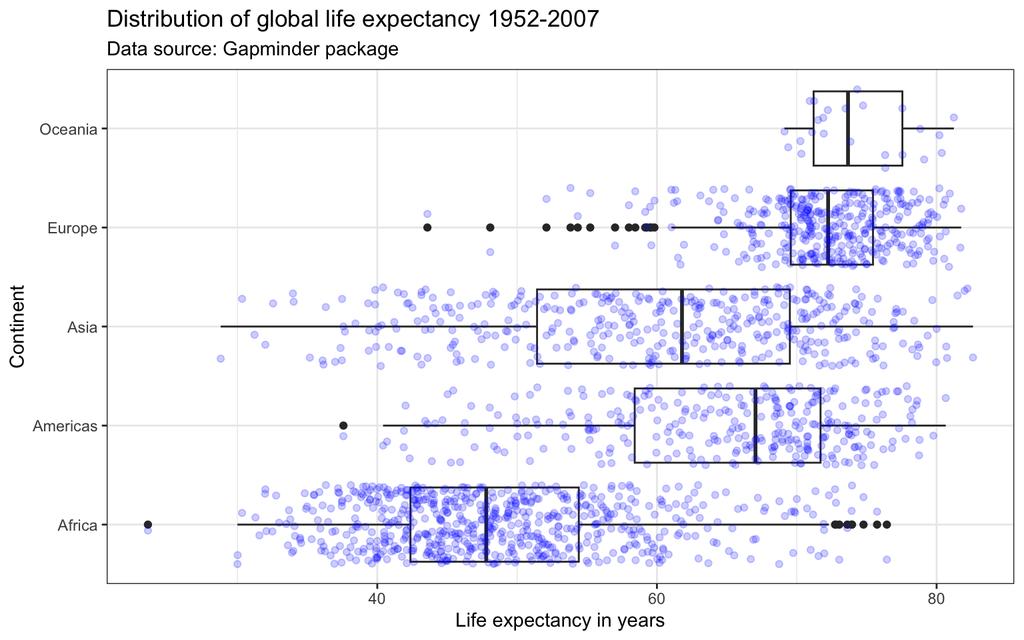

```r
ggplot(subset(df), aes(x = continent, y = lifeExp)) +
  geom_boxplot() +
  geom_jitter(alpha = 0.2, color = "blue") +
  labs(title = "Distribution of global life expectancy 1952-2007",
       subtitle = "Data source: Gapminder package",
       x = "Continent",
       y = "Life expectancy in years") +
  theme_bw() +
  coord_flip()
```

## Violin Plots 🎻

A violin plot is a compact display of a continuous distribution. It is a blend of `geom_boxplot()` and `geom_density()`: a violin plot is a mirrored density plot displayed in a similar way as a boxplot.

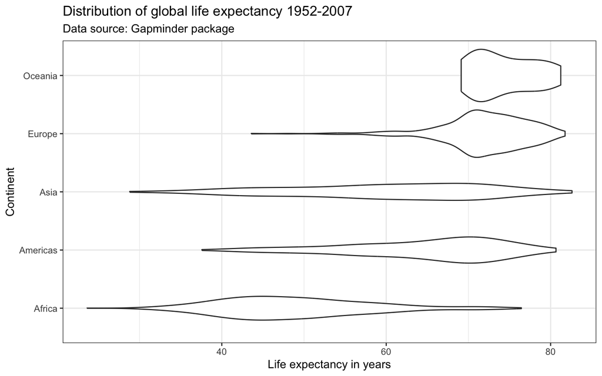

```r
ggplot(subset(df), aes(x = continent, y = lifeExp)) +
  geom_violin() +
  labs(title = "Distribution of global life expectancy 1952-2007",
       subtitle = "Data source: Gapminder package",
       x = "Continent",
       y = "Life expectancy in years") +
  theme_bw() +
  coord_flip()
```

## Exercise 2 - Distributions

Create a histogram showing the distribution of penguin body mass using the `penguins` dataset. As you explore the plot, try the following:

1. Choose an appropriate number of bins (for example, start with bins = 15 and adjust).
2. Set a fill color using fill = “red” or a hex code such as “#FF6666”.
3. Experiment with different geoms by replacing geom_histogram() with options like geom_density(), geom_bar(), or others.

```r
# YOUR CODE HERE
```

1. Now, look for a variable in the dataset that can be used to meaningfully group body mass. Use that variable to create a box plot or violin plot of body mass.

```r
# YOUR CODE HERE
```

# Plotting relationships 🤝

## Scatterplots

In their basic form, scatter plots are used to display values of two variables on a Cartesian coordinate system. Below, we inspect the relationship between GDP per capita and life expectancy.

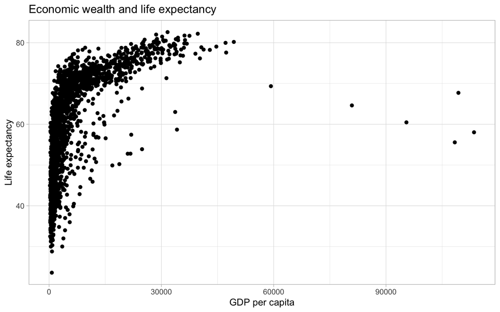

```r
ggplot(df, aes(x = gdpPercap, y = lifeExp)) +
  geom_point() +
  labs(title = "Economic wealth and life expectancy",
       x = "GDP per capita",
       y = "Life expectancy") +
  theme_light()
```

The plot above shows a large amount of clustering on the left side of the plot, while the right side of the plot is sparsely populated. This makes it hard to gauge the relationship between the two variables. Below, we make a few adjustments to the graph to better display the relationship.

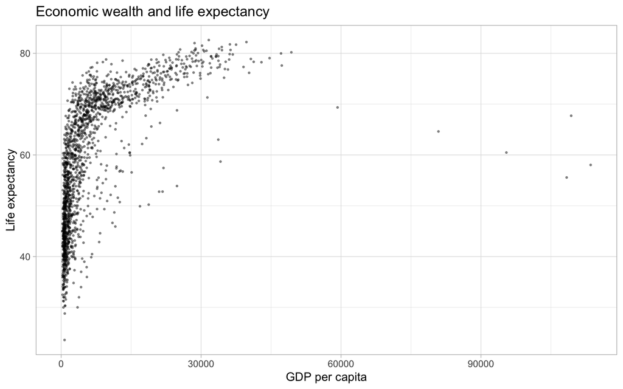

```r
ggplot(df, aes(x = gdpPercap, y = lifeExp)) +
  geom_point(alpha = 0.4,
             size = 0.5) +
  labs(title = "Economic wealth and life expectancy",
       x = "GDP per capita",
       y = "Life expectancy") +
  theme_light()
```

## Scaling the data

One reason why the plot above is hard to read is rooted in the shape of the distribution of the GDP per capita variable. GDP per capita has a strong right skew (yes, right, look at where the *tail* of the distribution is). Below we are plotting the average on top of the graph using the `geom_vline()`.

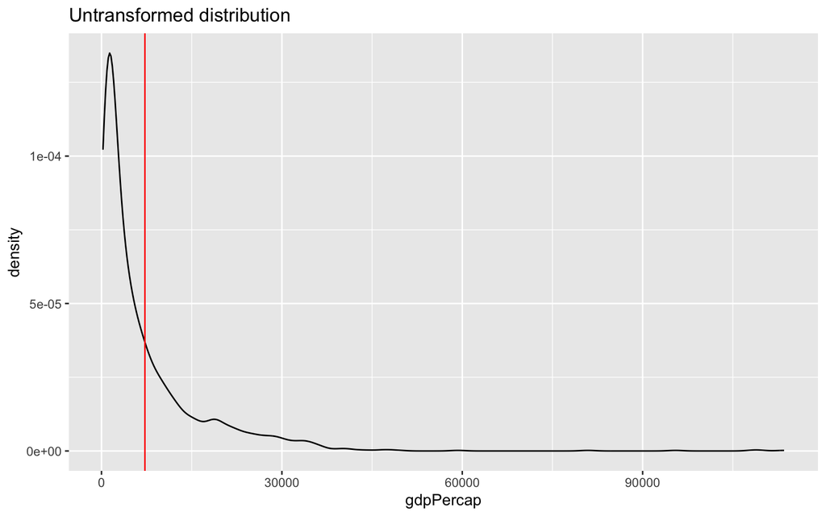

```r
av <-  mean(df$gdpPercap) # avg gpd per capita

ggplot(df,
       aes(x = gdpPercap)) +
  geom_line(stat = "density") +
  labs(title = "Untransformed distribution") +
  geom_vline(xintercept = av, color = "red") #try just typing 7215
```

We can correct for this skew and transform the variable to have a more “normal” distribution by taking the logarithm with base 10. There are multiple ways to do this.

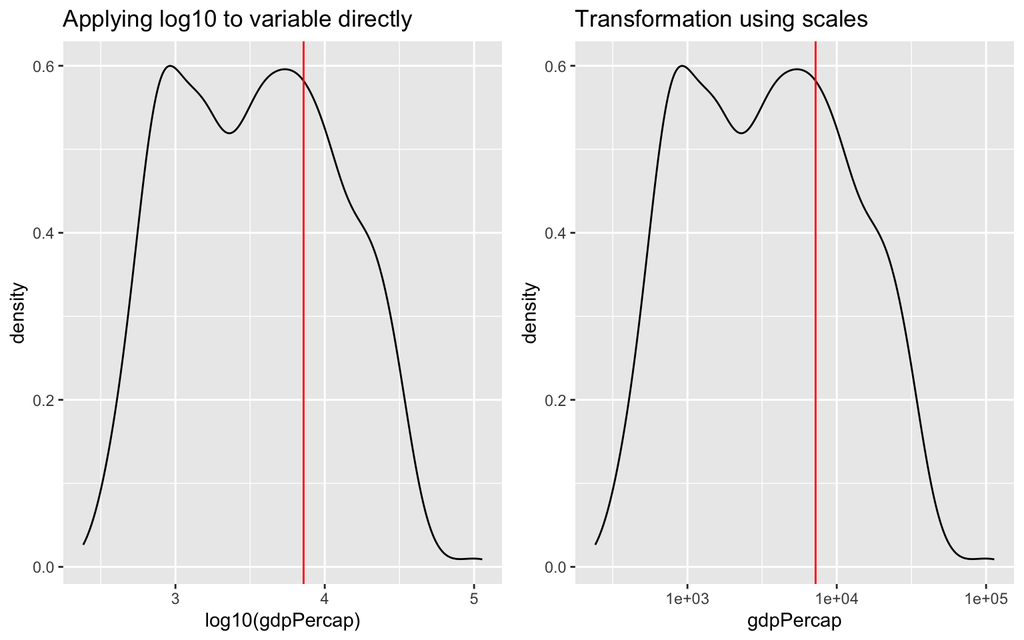

```r
log10_direct_plot <- ggplot(df, aes(x = log10(gdpPercap))) +
  geom_line(stat = "density") +
  labs(title = "Applying log10 to variable directly") +
  geom_vline(xintercept = log10(av), color = "red")

# Note below that we do NOT need to specify the av in terms of log10
# The entire x-axis is transformed
log10_via_scale_plot <- ggplot(df,
       aes(x = gdpPercap)) +
  geom_line(stat = "density") +
  labs(title = "Transformation using scales") +
  scale_x_log10() +
  geom_vline(xintercept = av, color = "red")

# Bonus: alternatively could also use scale_x_continuous(trans = "log10")

gridExtra::grid.arrange(log10_direct_plot, log10_via_scale_plot, ncol = 2)
```

We can use the same principle in bivariate (or multivariate) displays of data. Below, we use the `scale` transformation on the variable and reflect it in the axis label clarify that it is the relationship between life expectancy and the logarithm of GDP per capita that has a strong positive relationship.

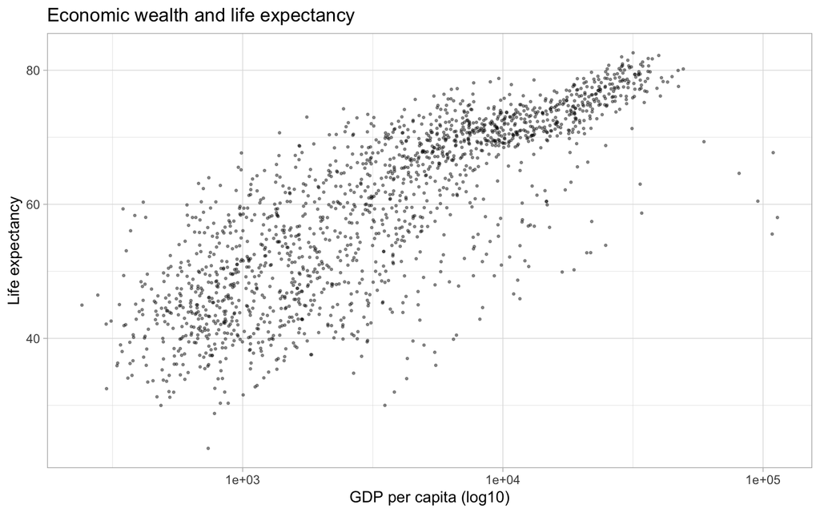

```r
ggplot(df, aes(x = gdpPercap, y = lifeExp)) +
  geom_point(alpha = 0.4,
             size = 0.5) +
  labs(title = "Economic wealth and life expectancy",
       x = "GDP per capita (log10)",
       y = "Life expectancy") +
  scale_x_log10() +
  theme_light()
```

## Adding trend lines

The plot above illustrates a strong positive relationship between GDP per capita and life expectancy. We can highlight the direction and strength of the relationship by adding a trend line using the [`geom_smooth()`](https://ggplot2.tidyverse.org/reference/geom_smooth.html) aesthetic.

The default smoothing method is `loess` for less than 1,000 observations and `gam` (Generalized Additive Models) for observations greater or equal to 1,000. `ggplot2` informs us which smoothing method was used via a message. By default, a 95% confidence interval is added to the trend line.

In our example, the trend line shows that the negative relationship at higher values of GDP per capita has a much lower precision than the positive relationship we observe for the majority of the observations.

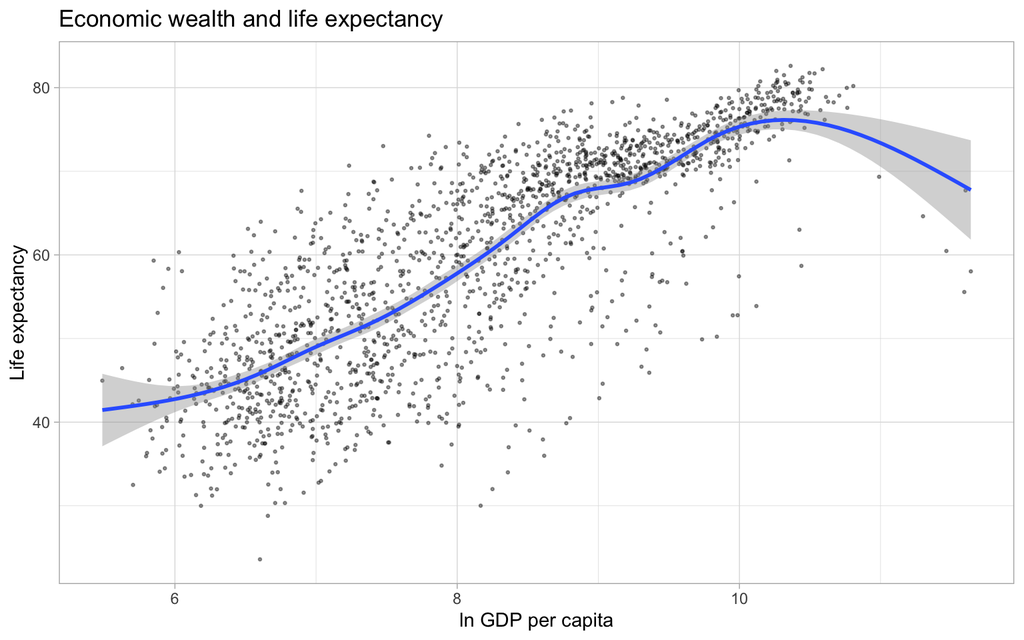

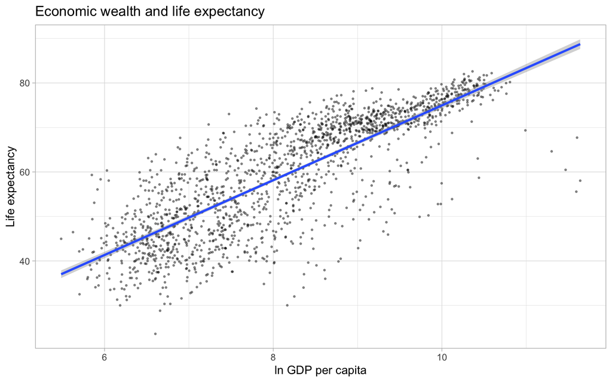

```r
ggplot(df, aes(x = log(gdpPercap), y = lifeExp)) +
  geom_point(alpha = 0.4,
             size = 0.5) +
  labs(title = "Economic wealth and life expectancy",
       x = "ln GDP per capita",
       y = "Life expectancy") +
  theme_light() +
  geom_smooth()

#Alternatively, we can add a linear trend line to the data.
ggplot(df, aes(x = log(gdpPercap), y = lifeExp)) +
  geom_point(alpha = 0.4,
             size = 0.5) +
  labs(title = "Economic wealth and life expectancy",
       x = "ln GDP per capita",
       y = "Life expectancy") +
  theme_light() +
  geom_smooth(method = "lm")
```

Finally, we can display separate trendlines for groups of data. For example, suppose we wanted to know how the relationship between GDP per capita and life expectancy varies by continent. We can pass the grouping variable to the `color` (and/or `linetype`) parameter within the `aes()` function. Below, we further reduce the opacity of the points to avoid overplotting. Note that the color grouping is passed to both the `geom_point()` and the `geom_smooth()` aesthetic.

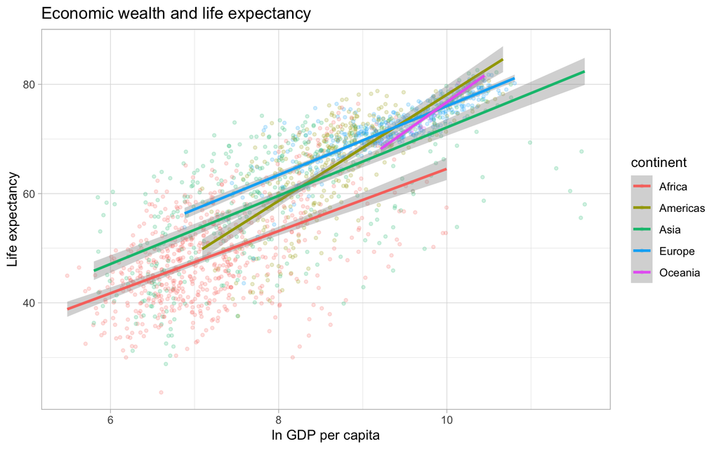

```r
ggplot(df, aes(x = log(gdpPercap),
               y = lifeExp,
               color = continent)) +
  geom_point(alpha = 0.2,
             size = 1) +
  labs(title = "Economic wealth and life expectancy",
       x = "ln GDP per capita",
       y = "Life expectancy") +
  theme_light() +
  geom_smooth(method = "lm")
```

## Line plots

Line plots are particularly useful for time series data. Below, we will graph the GDP per capita development of China from 1952 to 2007. We select the data for China by using the `subset()` function on the original data frame.

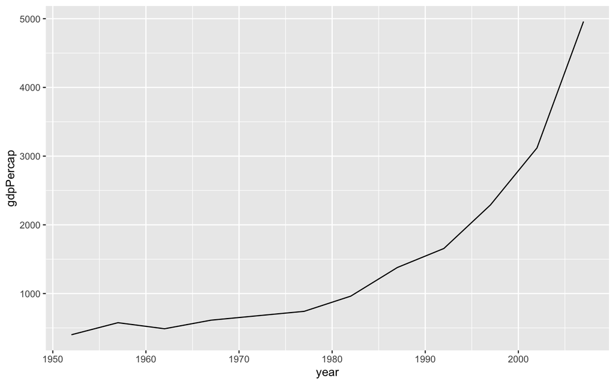

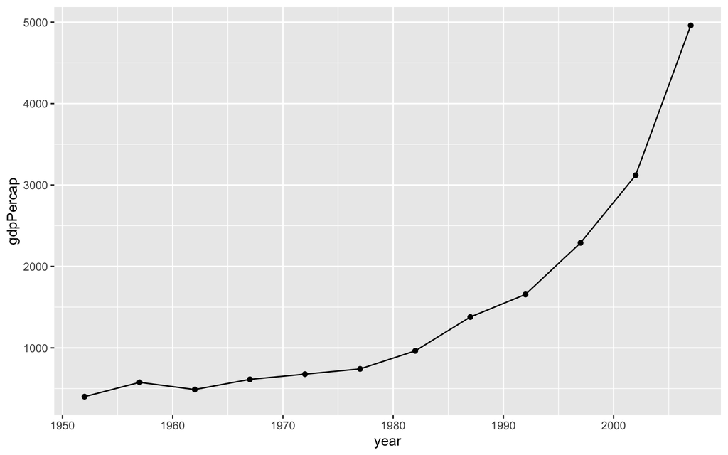

```r
ggplot(subset(df, country == "China"),
       aes(x = year,
           y = gdpPercap)) +
  geom_line()

# We can add points to the line to highlight which observations are available in the underlying data.
ggplot(subset(df, country == "China"),
       aes(x = year,
           y = gdpPercap)) +
  geom_line() +
  geom_point()
```

## Visualising multiple time series

To compare a time series across many units, we can plot all series in one figure using thin, low-opacity lines to keep the display readable. Here, we apply this approach to life expectancy over time and highlight China in red.

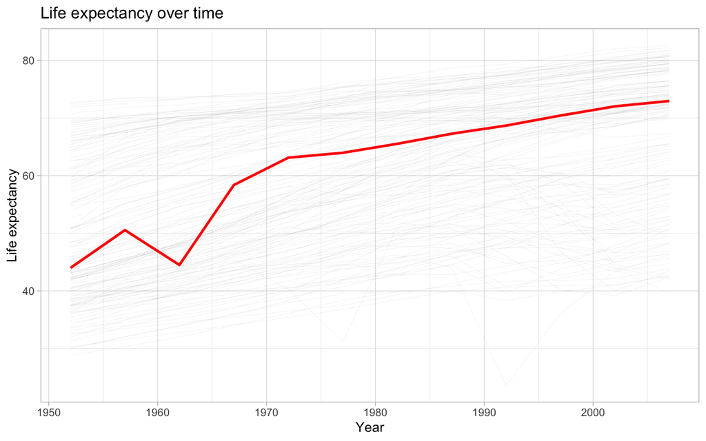

```r
ggplot(df,
       aes(x = year,
           y = lifeExp,
           group = country)) +
  geom_line(alpha = 0.1,
            linewidth = 0.1) +
  labs(title = "Life expectancy over time",
       x = "Year",
       y = "Life expectancy") +
  theme_light() +
  geom_line(data = subset(df, country %in% "China"),
            color = "red", linewidth = 1)
```

## Heatmaps

Heatmaps are another great way to illustrate trends for many different groups in data. Suppose, we were interested in the strength of the correlation between life expectancy and GDP per capita over time and space.

Below, we use our data wrangling skills from the last sessions to compute the correlation between the variables `lifeExp` and `gdpPercap` for each continent. Note that we exclude “Oceania” for this exercise.

```r
# Compute Pearson correlation coefficient by year and continent
cors <- df |>
  dplyr::filter(continent != "Oceania") |>
  dplyr::group_by(continent, year) |>
  dplyr::summarize(cor = cor(lifeExp, log10(gdpPercap)))
```

We can use the `geom_tile()` geom to create the heatmap; specifying the variable we want to display in color via the `fill` command. We can improve the left plot in a number of ways. First, the color scheme is not necessarily intuitive. The colors aren’t separated enough to best display smaller differences in the correlation coefficient, because they are based on the same hue. We can customize our colors to display a gradient with multiple hues.

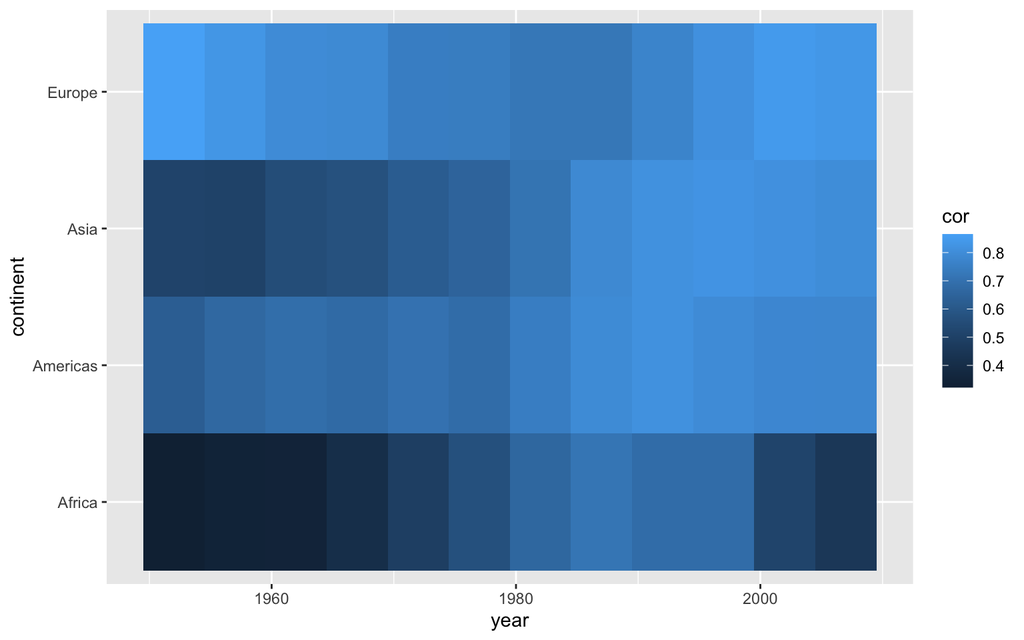

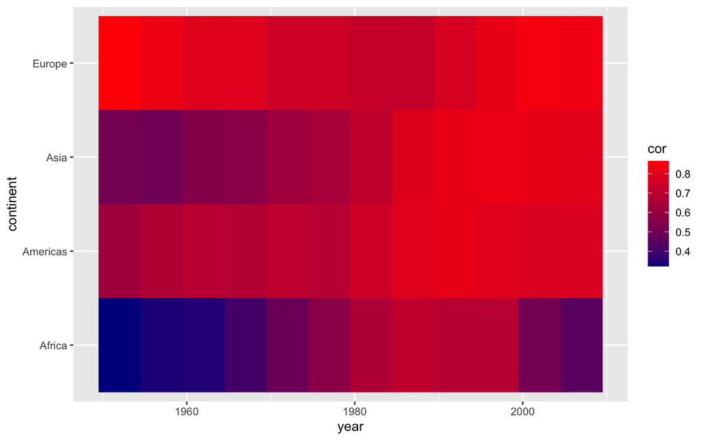

```r
ggplot(cors, aes(x = year, y = continent, fill = cor)) +
  geom_tile()

ggplot(cors, aes(x = year, y = continent, fill = cor)) +
  geom_tile() +
  scale_fill_gradient(low = "darkblue", high = "red")
```

We can also use existing color gradient schemes to better distinguish values in our plot. Below, we use color scales from the [viridis package](https://cran.r-project.org/web/packages/viridis/vignettes/intro-to-viridis.html). We also give the legend a more informative title.

Using color scales from the `viridis` package is a favorite among many who use `R` for data visualization. First developed for `matplotlib` in Python, this palette offers the following advantages:

- It is visually appealing
- *Perceptual uniformity*: visual perception of change is proportionate to incremental changes in the data.
- High contrast: optimal for printing in black-and-white and easier to read for people with color blindness[^1]

Second, we know that the correlation coefficient ranges from -1 to 1. We only have positive values here and they range from approximately 0.3 to 0.9. It is good practice to show at least one end point of the possible values in legends or axes. Therefore, below we extend the legend to display values from 0 to 1.

```r
ggplot(cors, aes(x = year, y = continent, fill = cor)) +
  geom_tile() +
  scale_fill_viridis(option = "inferno", name = "Correlation")

range(cors$cor)
```

```
## [1] 0.32 0.86
```

[figure not shown]

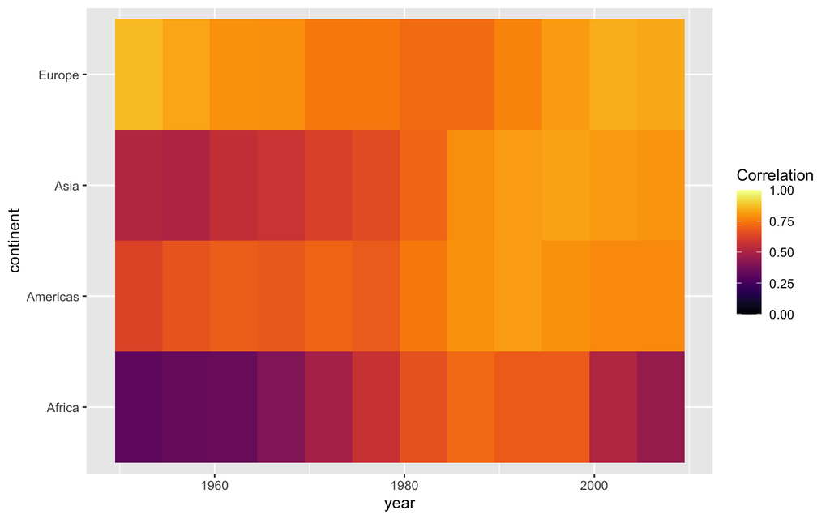

```r
ggplot(cors, aes(x = year, y = continent, fill = cor)) +
  geom_tile() +
  scale_fill_viridis(option = "inferno", name = "Correlation",
                     limits = c(0, 1))
```

Bonus: To improve on this graph, we can add some of the other elements offered by the `ggplot2` package.

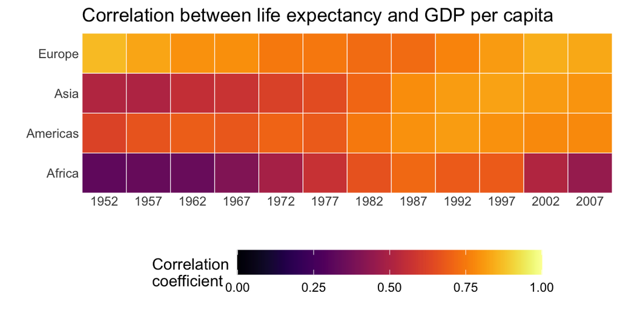

```r
ggplot(cors, aes(x = year, y = continent, fill = cor)) +
  geom_tile(color = "white") +
  scale_fill_viridis(option = "inferno", name = "Correlation\ncoefficient",
                     limits = c(0, 1)) +
  labs(x = "",
       y = "",
       title = "Correlation between life expectancy and GDP per capita") +

  # Changing appearance of the plot
  theme_light() +
  theme(panel.grid = element_blank(),
        legend.position = "bottom",
        legend.key.width = unit(1.5, "cm"),
        panel.border=element_blank(),
        axis.ticks = element_blank()) +

  # Adjust x axis labels
  scale_x_continuous(breaks = unique(cors$year)) +

  # Reduce space between plot and labels
  coord_cartesian(expand = 0)
```

## Barplots

Suppose we wanted to visualize global population growth over time. We might first want to compute the total population per continent and year.

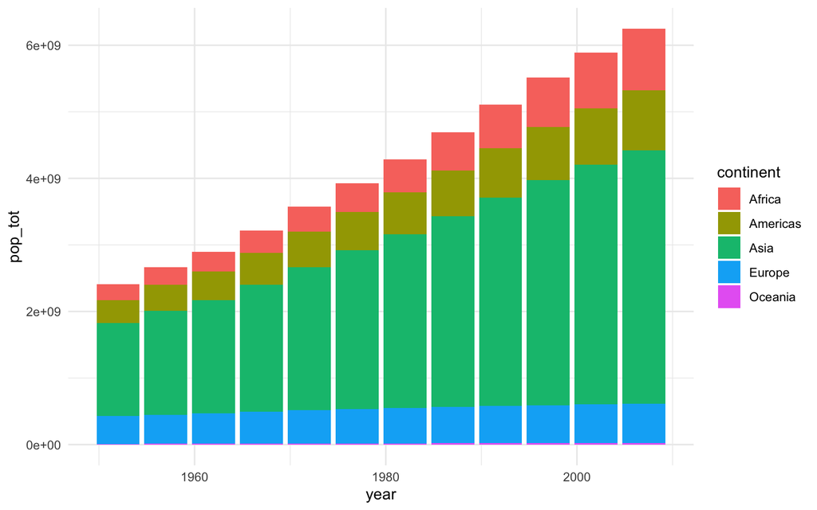

```r
globalpop <- df |>
  dplyr::group_by(continent, year) |>

  # Need to transform int to num to prevent integer overflow
  dplyr::summarize(pop_tot = sum(as.numeric(pop)))


# stacked
ggplot(globalpop, aes(x = year, y = pop_tot, fill = continent)) +
  geom_col() +
  theme_minimal()
```

`ggplot2()` is pretty nice and it just stacked each continent’s population on top of each other. If we instead wanted a separate bar for each continent, we can use the `position` parameter within `geom_col()`.

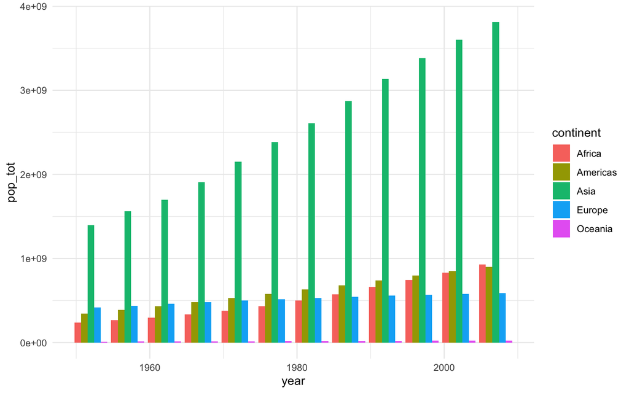

```r
# separate bars
ggplot(globalpop,
       aes(x = year, y = pop_tot, fill = continent)) +
  geom_col(position = position_dodge()) +
  theme_minimal()
```

Suppose we wanted to know which countries in Europe are shrinking and which countries are growing in terms of their population. We can use our data wrangling skills to compute the most recent change in population by taking the current value and subtracting the previous year’s value.

```r
diff07 <- df |>
  dplyr::group_by(country) |>
  dplyr::arrange(year) |>
  dplyr::mutate(fd = pop - dplyr::lag(pop))
```

Below, we plot the change in population for European countries in 2007.

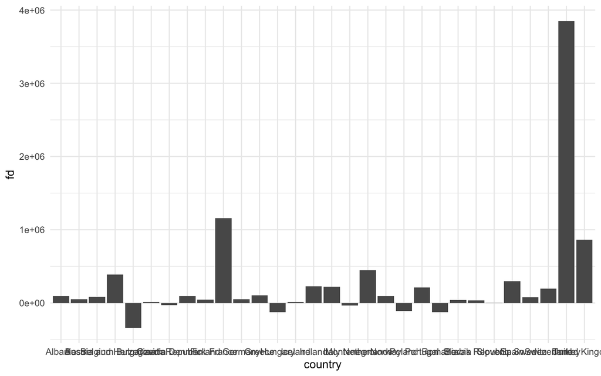

```r
ggplot(subset(diff07, continent == "Europe" & year == 2007),
       aes(x = country, y = fd)) +
  geom_col() +
  theme_minimal()
```

This is really hard to see. Let’s flip the axes using `coord_flip()`. This could useful because countries are ordered alphabetically, but visually, it is confusing. Let’s reorder the country axis based on the value of the population change. The default is to order the points in ascending order from the origin.

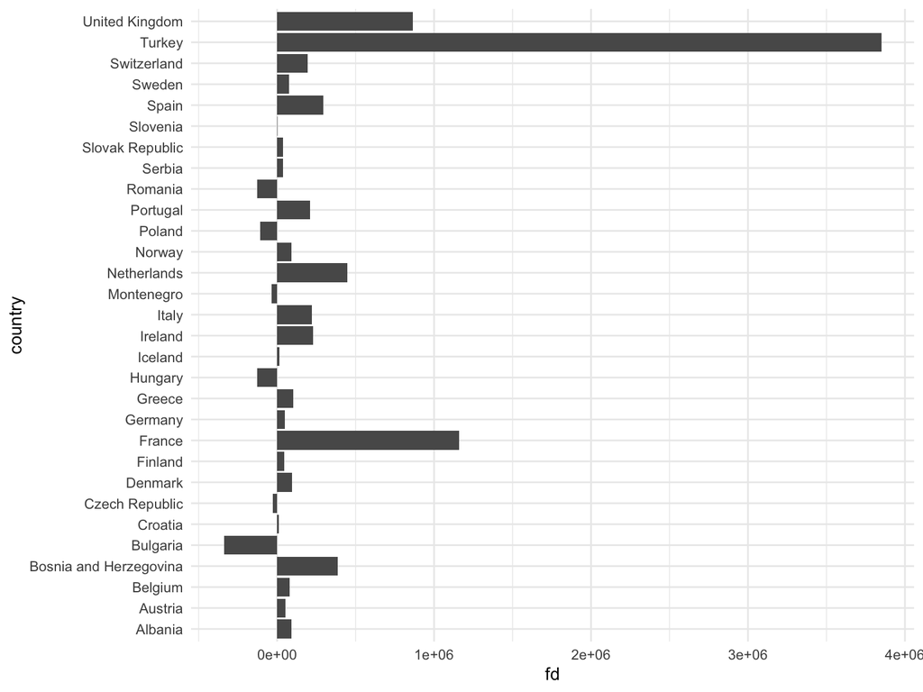

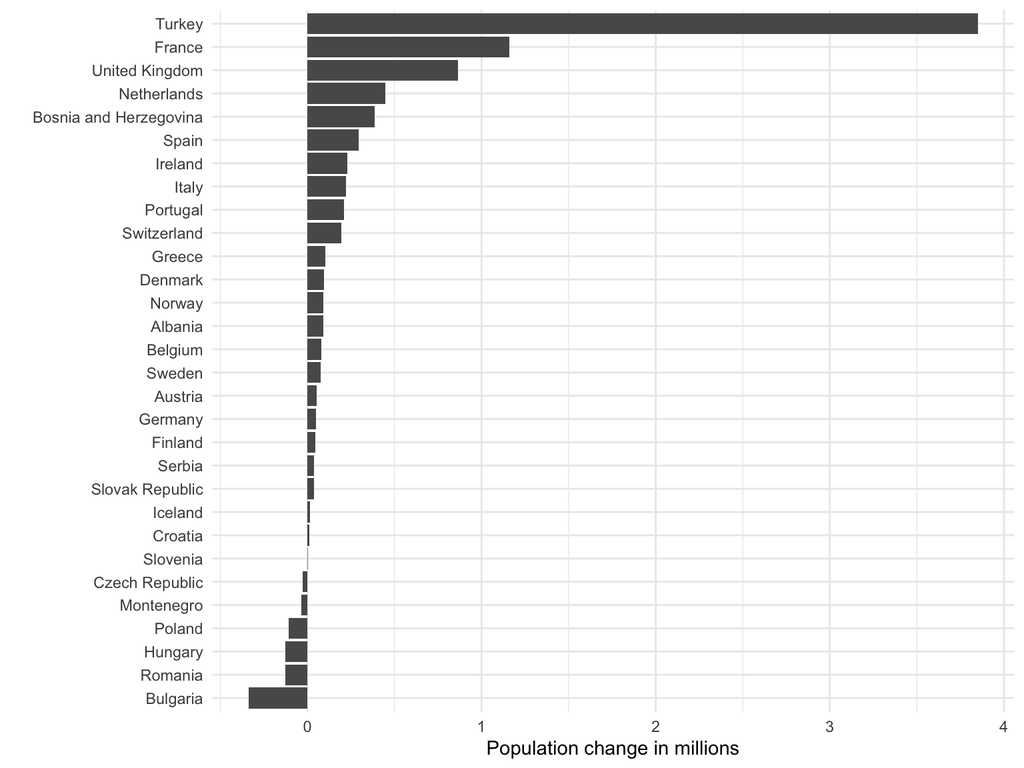

```r
ggplot(subset(diff07, continent == "Europe" & year == 2007),
       aes(x = country, y = fd)) +
  geom_col() +
  coord_flip() +
  theme_minimal()

ggplot(subset(diff07, continent == "Europe" & year == 2007),
       aes(x = reorder(country, fd), y = (fd/1e+6))) + # rearranging the axis
  geom_col() +
  coord_flip() +
  labs(x = "", y = "Population change in millions") +
  theme_minimal()
```

## Exercise 3 - Relationships

Create a scatter plot to explore the relationship between `flipper_length_mm` and `body_mass_g`. Then, color by a grouping variable (of your choice) and add linear trend lines.

```r
# YOUR CODE HERE
```

# Graph appearance 💅

The default graphs we have produced so far are not (yet) ready for publication. In particular, they lack informative labels. In addition, we might want to change the appearance of the graph in terms of size, color, linetype, etc.

## Title, subtitle, and axes titles

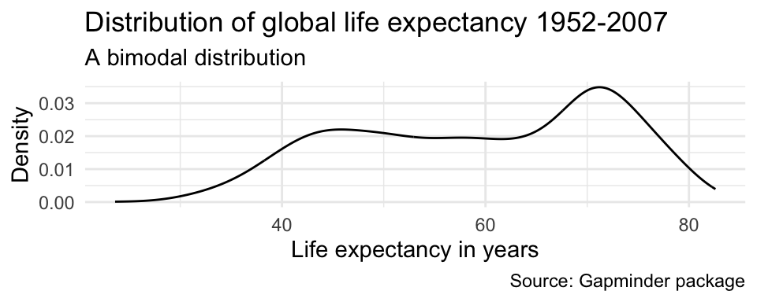

```r
ggplot(df,aes(x = lifeExp)) +
  geom_line(stat = "density") +
  labs(title = "Distribution of global life expectancy 1952-2007",
       subtitle = "A bimodal distribution",
       caption = 'Source: Gapminder package',
       x = "Life expectancy in years",
       y = "Density") +
  theme_minimal()
```

## Axis ranges

By default, `ggplot()` adjusted the x-axis to start not at zero but at approximately 23 to reduce the amount of empty space in the plot. We can manually adjust the range of the axes using the `coord_cartesian()` parameter.

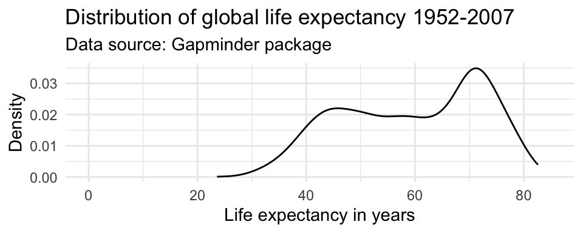

```r
ggplot(df, aes(x = lifeExp)) +
  geom_line(stat = "density") +
  labs(title = "Distribution of global life expectancy 1952-2007",
       subtitle = "Data source: Gapminder package",
       x = "Life expectancy in years",
       y = "Density") +
  coord_cartesian(xlim = c(0, 85)) +
  theme_minimal()
```

**Caution!**

You will sometimes see the command `scale_y_continuous(limits = c(0, 85))` instead of `coord_cartesian(ylim = c(0, 85))`. Note that these are not the same. `coord_cartesian()` only adjusts the range of the axes (it “zooms” in and out), while `scale_y_continuous(limits = c())` subsets the data. For density plots, this does not make a difference. But there are other examples where it alters the actual shape of the graph, rather than just the part of the graph that is visible.